# Lab_04: Roberto’s Exercises

Roberto Corti

08/05/2020

# DAAG Chapter 6

## Exercise 06

**The following investigates the consequences of not using a logarithmic transformation for the nihills data analysis. The second differs from the first in having a `dist x climb` interaction term, additional to linear terms in `dist` and `climb`.**

- **Fit the two models**:

```r
library(DAAG)
data(nihills)
nihills.lm <- lm(time ~ dist+climb, data=nihills)
nihills2.lm <- lm(time ~ dist+climb+dist:climb, data=nihills)
anova(nihills.lm, nihills2.lm)
```

- **Using the F-test result, make a tentative choice of model, and proceed to examine diagnostic plots. Are there any problematic observations? What happens if these points are removed? Refit both of the above models, and check the diagnostics again**

In order to compare the two models, let’s run the above code:

```r
nihills.lm <- lm(time ~ dist+climb, data=nihills)
nihills2.lm <- lm(time ~ dist+climb+dist:climb, data=nihills)
anova(nihills.lm, nihills2.lm)
```

```
## Analysis of Variance Table
##
## Model 1: time ~ dist + climb
## Model 2: time ~ dist + climb + dist:climb
##   Res.Df      RSS Df Sum of Sq      F    Pr(>F)
## 1     20 0.189361
## 2     19 0.039361  1      0.15 72.406 6.623e-08 ***
## ---
## Signif. codes:  0 '***' 0.001 '**' 0.01 '*' 0.05 '.' 0.1 ' ' 1
```

The result of the $F$ test give raise to a p-value, which is the probability that the $F$ statistics is grater than the one observed assuming the null hypotesis that the coefficient relative to `dist x climb` , is quite low. Thus we can reject the null hypotesis and therefore say that `nihills2.lm`, that is, the most complex model including an interaction term, appears as significantly better than Model 1 for `nihills` data.

For having a more precise view of the two models we proceed to examine the diagnostic plots:

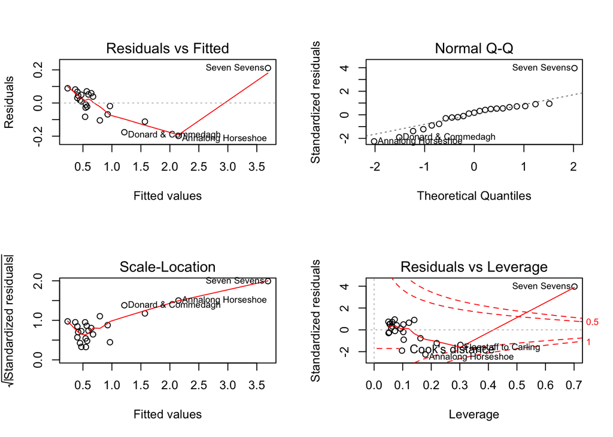

```r
## model: time = b0 + b1 dist + b2 climb
par(mfrow=c(2,2))
plot(nihills.lm)
```

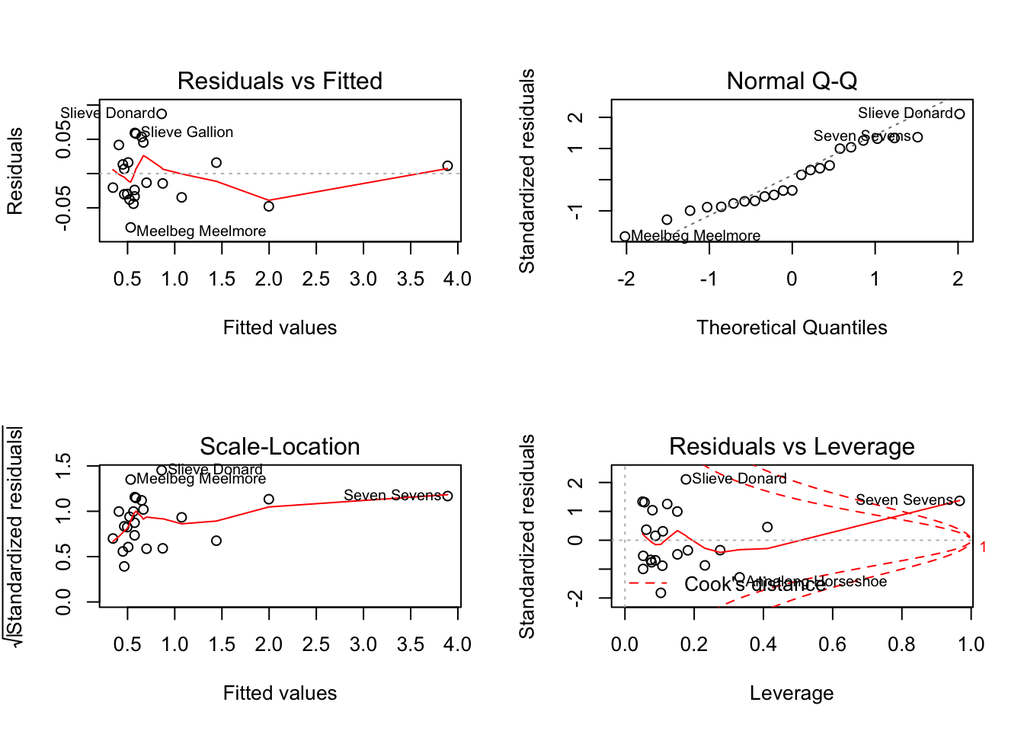

```r
## model: time = b0 + b1 dist + b2 climb + b3 (dist x climb)
par(mfrow=c(2,2))
plot(nihills2.lm)
```

Looking to these plots of the two fit at first istance we observe that Seven Sevens obs. looks to be a suspect point. This point has an unexpected residual and looks to have a large influence to the fit. In fact, the `Residual vs Leverage` plot suggest that this point has a very large leverage. We think that `Seven Sevens` observation is clearly an outlier that has a great impact on the fit. Moreover, from the diganostic plot of `nihills.lm` we also suspect that the points `Annalong Horseshoe`, `Flagstaff to Carling`’ seems problematic since they result to have an unexpected distribution of their residuals. Looking to the plots of `nihill.lm2` we see that `Slieve Donard` and `Meelbeg Meelmore` also have high residuals.

Thus, we decide to remove all of these suspected points:

```r
nihills <- nihills[rownames(nihills) != "Seven Sevens",]
nihills <- nihills[rownames(nihills) != "Annalong Horseshoe",]
nihills <- nihills[rownames(nihills) != "Slieve Donard",]
nihills <- nihills[rownames(nihills) != "Meelbeg Meelmore",]
nihills <- nihills[rownames(nihills) != "Flagstaff to Carling",]
```

Without these points we do the two fits another time and we are going to see whether the $F$-test is still rejected:

```r
# Refit models
nihills.lm <- lm(time ~ dist + climb, data = nihills)
nihills2.lm <- lm(time ~ dist + climb + dist:climb, data = nihills)
anova(nihills.lm, nihills2.lm)
```

```
## Analysis of Variance Table
##
## Model 1: time ~ dist + climb
## Model 2: time ~ dist + climb + dist:climb
##   Res.Df      RSS Df  Sum of Sq      F Pr(>F)
## 1     15 0.020572
## 2     14 0.020389  1 0.00018262 0.1254 0.7285
```

After removing the problematic points, the $F$-test on the new fitted models shows that there is no significant improvement in the more complex model over the simple one.

The previous tentative choice was a mistake driven by outliers. Without them, there’s no statistical justification that prefers one model respect to the other.

## Exercise 08

**Apply the `lm.ridge()` function to the litters data, using the generalized cross-validation (GCV) criterion to choose the tuning parameter. (GCV is an approximation to cross-validation.)**

- **In particular, estimate the coefficients of the model relating `brainwt` to `bodywt` and `lsize` and compare with the results obtained using `lm()`.**
- **Using both ridge and ordinary regression, estimate the mean brain weight when litter size is 10 and body weight is 7. Use the bootstrap, with case-resampling, to compute approximate 95% percentile confidence intervals using each method. Compare with the interval obtained using `predict.lm()`.**

```r
library(MASS)
data(litters)

#GCV on ridge regression
MASS::select(lm.ridge(brainwt~., data=litters, lambda = seq(0,1,0.001)))
```

```
## modified HKB estimator is 0
## modified L-W estimator is 0
## smallest value of GCV  at 0.118
```

Then the optimized value of the parameter $\lambda$ is 0.118. We now use this value and we compare simple multiple linear regression with multiple ridge regression:

```r
litters_lm <- lm(brainwt~., data=litters)
litters_lm
```

```
##
## Call:
## lm(formula = brainwt ~ ., data = litters)
##
## Coefficients:
## (Intercept)        lsize       bodywt
##     0.17825      0.00669      0.02431
```

```r
litters_lm_ridge <- lm.ridge(brainwt~., data=litters, lambda = 0.118)
litters_lm_ridge
```

```
##                   lsize      bodywt
## 0.203442601 0.005661579 0.022050278
```

For ridge regression case both `bodywt` and `lsize` coefficients are penalized in favor of the intercept.

In order to obtain the 95% percentile confidence intervals with bootstrap sampling we decided to build the following two functions that, given the formula model, the data, the number of bootsrap repetitions and the regularization parameter $\lambda$ would give as output the 95% confidence intervale for the value of `brainwt` when `lsize = 10` and `bodywt = 7`.

```r
bootsrap_lm <- function(formula, data, repetitions){
  n <- nrow(data)
  B <- repetitions
  s_vect <- array(0, B)
  for(i in 1:B) {
    ind <- sample(1:n, n, replace = TRUE)
    lm.b<-lm(formula, data=data[ind,])
    s_vect[i] <- lm.b$coefficients[1] + lm.b$coefficient[2]*10 + lm.b$coefficient[3]*7
  }
  perc_ci <- quantile(s_vect, prob=c(0.025, 0.975))
  return(perc_ci)
}

bootsrap_lm_ridge <- function(formula, data, repetitions, lambda){
  n <- nrow(data)
  B <- repetitions
  s_vect <- array(0, B)
  for(i in 1:B) {
    ind <- sample(1:n, n, replace = TRUE)
    lm.b<-lm.ridge(formula, data=data[ind,], lambda=lambda)
    s_vect[i] <- coef(lm.b)[1] + coef(lm.b)[2]*10 + coef(lm.b)[3]*7
  }
  perc_ci <- quantile(s_vect, prob=c(0.025, 0.975))
  return(perc_ci)
}
```

```r
bootsrap_lm(formula=brainwt~., data=litters, repetitions = 10^4)
```

```
##      2.5%     97.5%
## 0.4054396 0.4233217
```

```r
bootsrap_lm_ridge(formula=brainwt~., data=litters, repetitions = 10^4, lambda = 0.118)
```

```
##      2.5%     97.5%
## 0.4043808 0.4220798
```

```r
estimate <- data.frame(lsize=10, bodywt=7)
predict.lm(lm(brainwt~., data=litters), estimate, interval = "confidence")
```

```
##         fit       lwr       upr
## 1 0.4152947 0.4062582 0.4243312
```

# DAAG Chapter 8

## Exercise 03

**Consider again the moths data set of Section 8.4.**

- **What happens to the standard error estimates when the poisson family is used in glm() instead of the quasipoisson family?**
- **Analyze the `P` moths, in the same way as the `A` moths were analyzed. Comment on the effect of transect length.**

```r
data("moths")
moths$habitat <- relevel(moths$habitat, ref="Lowerside")
summary(A.glm <- glm(A ~ habitat + log(meters), family=quasipoisson, data=moths))
```

```
##
## Call:
## glm(formula = A ~ habitat + log(meters), family = quasipoisson,
##     data = moths)
##
## Deviance Residuals:
##     Min       1Q   Median       3Q      Max
## -3.5562  -1.4635  -0.0007   0.9248   3.0822
##
## Coefficients:
##                    Estimate Std. Error t value Pr(>|t|)
## (Intercept)         1.20981    0.45530   2.657   0.0122 *
## habitatBank       -16.90566 2096.58841  -0.008   0.9936
## habitatDisturbed   -1.28323    0.64737  -1.982   0.0561 .
## habitatNEsoak      -0.82170    0.53700  -1.530   0.1358
## habitatNWsoak       1.56243    0.33426   4.674 5.11e-05 ***
## habitatSEsoak       0.06206    0.38515   0.161   0.8730
## habitatSWsoak       0.23143    0.47807   0.484   0.6316
## habitatUpperside   -0.16234    0.58429  -0.278   0.7829
## log(meters)         0.12917    0.15278   0.845   0.4041
## ---
## Signif. codes:  0 '***' 0.001 '**' 0.01 '*' 0.05 '.' 0.1 ' ' 1
##
## (Dispersion parameter for quasipoisson family taken to be 2.700801)
##
##     Null deviance: 257.108  on 40  degrees of freedom
## Residual deviance:  93.991  on 32  degrees of freedom
## AIC: NA
##
## Number of Fisher Scoring iterations: 13
```

```r
summary(A.glm <- glm(A ~ habitat + log(meters), family=poisson, data=moths))
```

```
##
## Call:
## glm(formula = A ~ habitat + log(meters), family = poisson, data = moths)
##
## Deviance Residuals:
##     Min       1Q   Median       3Q      Max
## -3.5562  -1.4635  -0.0007   0.9248   3.0822
##
## Coefficients:
##                    Estimate Std. Error z value Pr(>|z|)
## (Intercept)         1.20981    0.27705   4.367 1.26e-05 ***
## habitatBank       -16.90566 1275.75387  -0.013  0.98943
## habitatDisturbed   -1.28323    0.39392  -3.258  0.00112 **
## habitatNEsoak      -0.82170    0.32676  -2.515  0.01191 *
## habitatNWsoak       1.56243    0.20340   7.682 1.57e-14 ***
## habitatSEsoak       0.06206    0.23436   0.265  0.79114
## habitatSWsoak       0.23143    0.29090   0.796  0.42628
## habitatUpperside   -0.16234    0.35554  -0.457  0.64796
## log(meters)         0.12917    0.09297   1.389  0.16471
## ---
## Signif. codes:  0 '***' 0.001 '**' 0.01 '*' 0.05 '.' 0.1 ' ' 1
##
## (Dispersion parameter for poisson family taken to be 1)
##
##     Null deviance: 257.108  on 40  degrees of freedom
## Residual deviance:  93.991  on 32  degrees of freedom
## AIC: 226.71
##
## Number of Fisher Scoring iterations: 13
```

```r
sapply(split(moths$P, moths$habitat), sum)
```

```
## Lowerside      Bank Disturbed    NEsoak    NWsoak    SEsoak    SWsoak
##        17         4        33        14        19         6        48
## Upperside
##         8
```

```r
moths$habitat <- relevel(moths$habitat, ref="Lowerside")

P.glm <- glm(P ~ habitat + log(meters), family=quasipoisson, data=moths)

P.glm
```

```
##
## Call:  glm(formula = P ~ habitat + log(meters), family = quasipoisson,
##     data = moths)
##
## Coefficients:
##      (Intercept)       habitatBank  habitatDisturbed     habitatNEsoak
##          -0.8608            0.5569            1.4364           -0.3211
##    habitatNWsoak     habitatSEsoak     habitatSWsoak  habitatUpperside
##           1.0106           -1.0697            1.6383           -1.5773
##      log(meters)
##           0.5552
##
## Degrees of Freedom: 40 Total (i.e. Null);  32 Residual
## Null Deviance:       217.8
## Residual Deviance: 76.92     AIC: NA
```